# CRAVENS - Part 2 Excercies

### Cluster 10: Fitness Enthusiest

Cluster ten had high scores in *health nutrition*, *outdoors*, and *personal fitness*, and medium scores in food, cooking, and eco. Based on these characteristics, we classify this cluster as fitness enthusiast.

To better picture these clusters, I put together a plot for each cluster (excluding Bots & Uncharacterized) showing dots for different users along the scale of two primary factors. Each dot is colored in with the cluster. You will see for each graph, the cluster being highlighted dominates the graph!

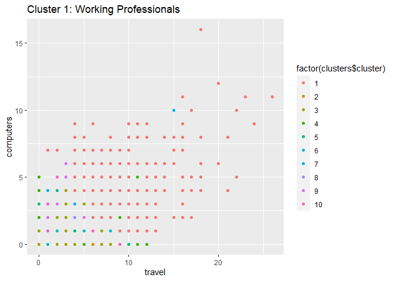

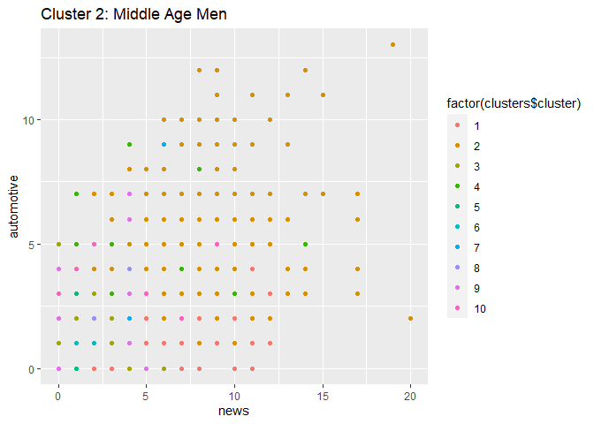

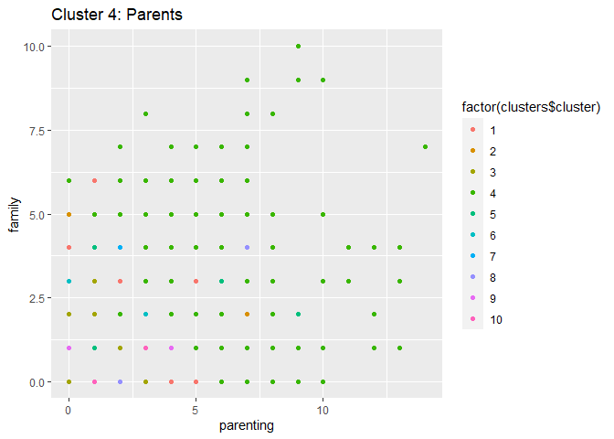

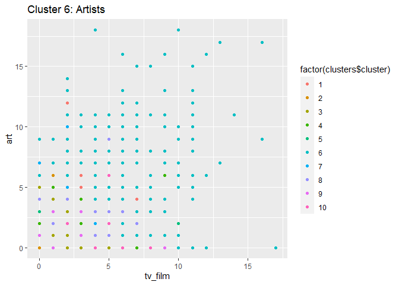

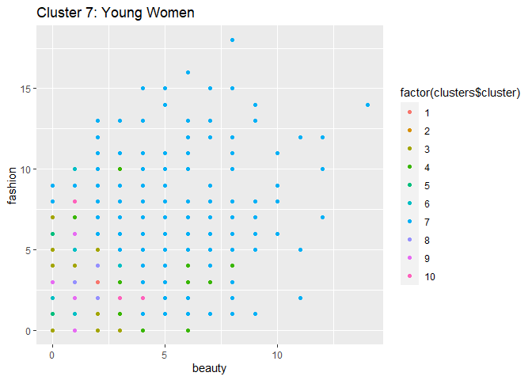

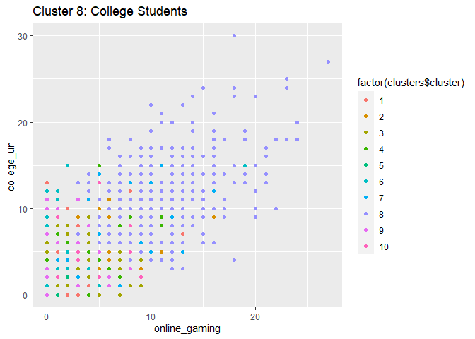

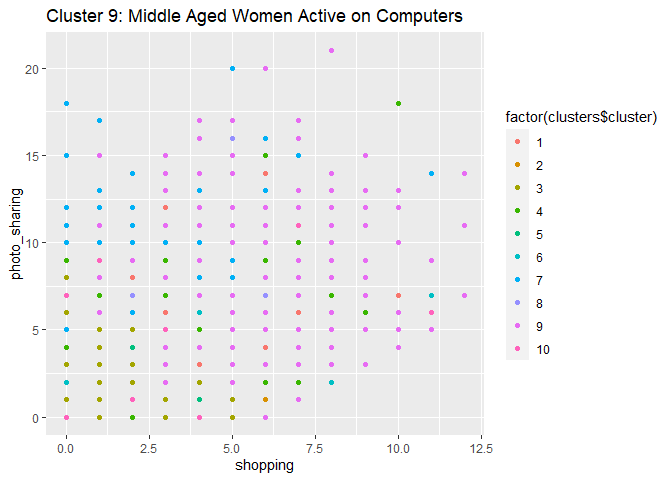

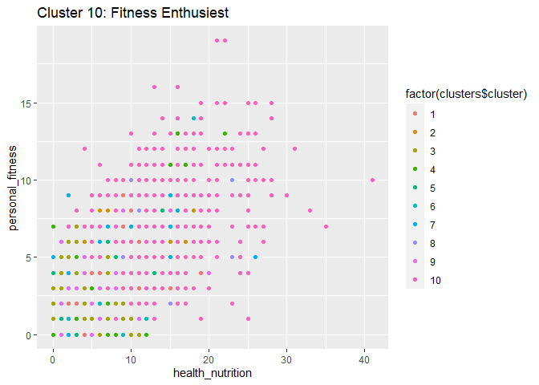

## Summary

We saw a total of 10 different clusters, all with different sizes:

```
##    Cluster                Characteristic Cluster.Size Percent.of.Audience
## 1        1         Working Professionals          349                   4
## 2        2                Middle Age Men          428                   5
## 3        3               Uncharacterized         3251                  41
## 4        4                       Parents          664                   8
## 5        5                          Bots          214                   3
## 6        6                       Artists          387                   5
## 7        7                   Young Women          468                   6
## 8        8              College Students          351                   4
## 9        9 Middle age women on computers         1019                  13
## 10      10            Fitness Enthusiest          751                  10
```

While we would ideally trim down the uncharacterized users to a unique group, increasing the number of clusters makes other categories too small (less than 2%) and therefore take away from the overall effectivness of market segmentation for business implenetation.

# **Question 5** Author Attribution

TASK: predict the author of an article based on textual content

## Data Pre-Processing

The process of analyzing text is cumbersome and at times, confusing.

### Step 1: Import Libraries

We imported the following libraries: *tm, magrittr, slam, proxy, tibble, dplyr*. Please import.

### Step 2: Set Up Reader Function

We were given 50 articles from each of the 50 different authors (in different folders or directories) in text documents. The *tm* library has many reader functions, we will use *readPlain* for our text documents. However, to easier analyze, we will wrap the readPlain function to ensure the lines are being read in English:

### Step 3: Read in Documents

We have 50 different folders (one for every author) each with 50 different documents. We want to extract the names of each of these documents so we can read each of them in. We will need to do the following:

- Set working directory to outside file location (the folder where train and test folders sit)
- For both train and test, make a list of the 50 directories within those folders
  - Reminder: each directory is a different author name!
- Iterate over the 50 directories and add each file’s name to a singular list (separate lists for test and train)
  - This means pasting the directory names in and adding a wildcard into the filename path (‘globbing’)
- Apply reader function to these list to read in files
- Clean list of names so that directory is not included in title and rename the articles in vector
- From each vector (train and test), create a text mining corpus

### Step 4: Clean Document

For both corpus ‘documents’, we must clean it up for more clean analysis:

- Remove capitalization
- Remove numbers
- Remove punctuation
- Remove extra white spaces
- Remove stop words (basic words like I, the, etc.) that are common English

### Step 5a: FOR TRAIN: create term matrix and remove sparse data

There is a lot of noise within these documents with many words appearing very little. To remove the noise for better analysis, we removed those terms that have count 0 in >90% of docs. This made our matrix shrink exponentially from over 80 million entries (32K+ terms for 2,500 documents) to less than 1 million (396 terms for the 2,500 documents).

### Step 5b: FOR TEST: Create term matrix

For our test matrix, we only included words that were in the train test for a clean analysis.

### Step 6: Construct TF IDF weights

To note, we will use these weights in SOME but not all of our models. It helps ‘normalizes’ the terms of each document so that the length of the document does not skew results.

## Analyzing with Various Models

### PCA (using TF IDF weights) so we can feed into LOGISTIC REGRESSION & RANDOM FOREST

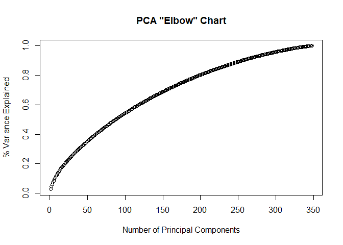

Thus, we need to narrow down a test and train matrices with PCA:

- Select the 140 PCA components on train test (x train values)
- Predict the 140 components on the test (x test values)
- Extract Author names for both test and train (our y values)

### Logistic Regression on PCA

Using Logistic Regression on our PCA Components, we get the following accuracy:

```
## [1] 0.3732
```

### Random Forest

Using Random Forest on our PCA Components, we get the following accuracy:

```
## [1] 0.676
```

### Naive Bayes

Using Naive Bayes on our PCA Components, we get the following accuracy:

```
## [1] 0.4612
```

## Conclusion:

Considering the three models we ran, we found that Random Forest is the most accurate model.

# **Question 6** Association Rule Mining

## Set up one dataframe

Our data was in a messy table, so in order to analyze, we put all items in one column and their basket number in the second.

## Most popular items

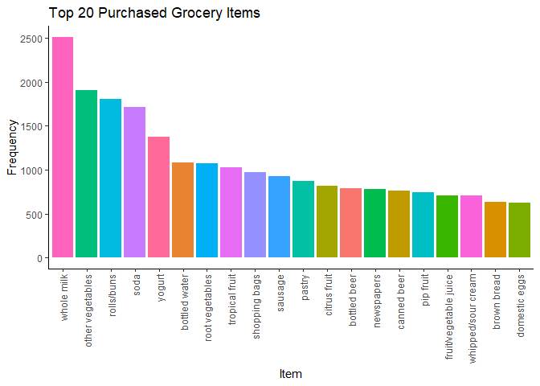

## Set up Association Rules

Depending on the levels of support and confidence we use, a different number of rules will be outputted. We landed on using a support of 0.005 and confidence of 0.05. This narrowed down our rules to 181.

[output not shown]

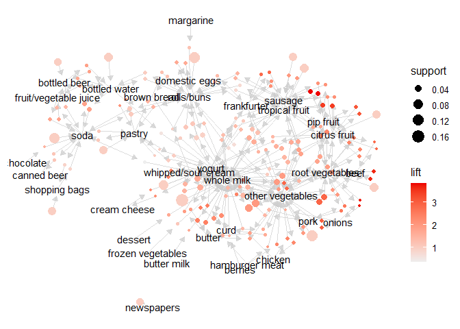

## Most Correlated Items (high lift)

First, we examined the top 15 association rules by lift - meaning the highest correlated items. We can see it is a lot of fruit and vegetable items together. This aligns to how grocery stores group produce together.

```
##                               lhs                   rhs     support confidence
## [1]                   {pip fruit} =>   {tropical fruit} 0.012683054 0.26075269
## [2]              {tropical fruit} =>        {pip fruit} 0.012683054 0.18798450
## [3]             {root vegetables} =>           {onions} 0.005295502 0.07555970
## [4]                      {onions} =>  {root vegetables} 0.005295502 0.26557377
## [5]                        {beef} =>  {root vegetables} 0.008695084 0.25775194
## [6]             {root vegetables} =>             {beef} 0.008695084 0.12406716
## [7]                {citrus fruit} =>   {tropical fruit} 0.012486925 0.23464373
## [8]              {tropical fruit} =>     {citrus fruit} 0.012486925 0.18507752
## [9]                   {pip fruit} =>     {citrus fruit} 0.008172071 0.16801075
## [10]               {citrus fruit} =>        {pip fruit} 0.008172071 0.15356265
## [11]           {other vegetables} =>           {onions} 0.007452929 0.05990541
## [12]                     {onions} => {other vegetables} 0.007452929 0.37377049
## [13]            {root vegetables} => {other vegetables} 0.025366109 0.36194030
## [14]           {other vegetables} =>  {root vegetables} 0.025366109 0.20388860
```

[output cut: 17 more lines]

## Individual Item Analysis

Next, we examined what people are buying with our most frequently bought items. Below are a few interesting findings:

### Whole Milk

We see people that buy vegetables and tropical fruit. We should keep the milk close to the produce section.

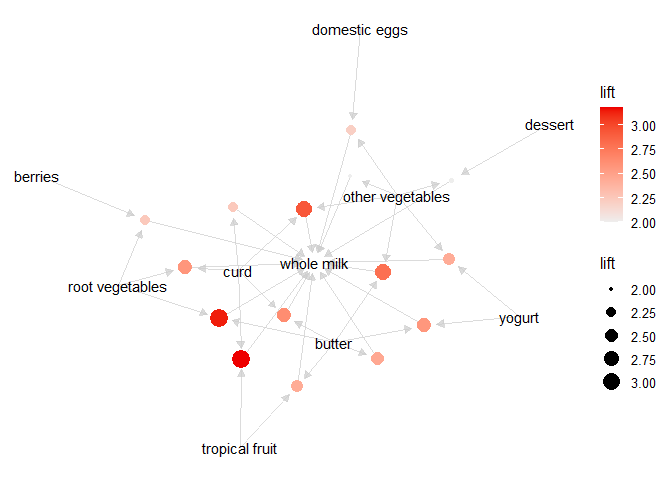

### Rolls/ Buns:

People who buy sausage, soda, and cheeses tend to also buy rolls/ buns. It may be beneficial to have a small shelf of bread or maybe an entire bakery section near a meat and cheese section.

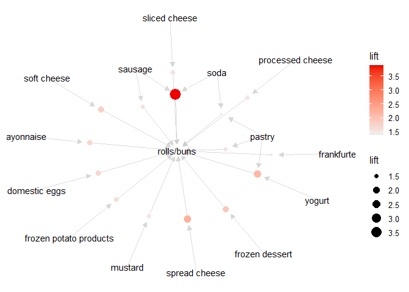

### Pastry:

People who buy other breads and a few dairy products tend to buy pastries. Again, why a bakery and meat & cheese section together would be beneficial.

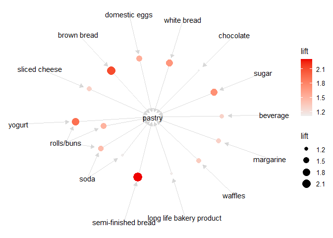

### Soda:

People who buy other drinks such as bottled water, beer and juices tend to also buy soda. So, it is helpful to have a drink section in a store where you find all drinks.

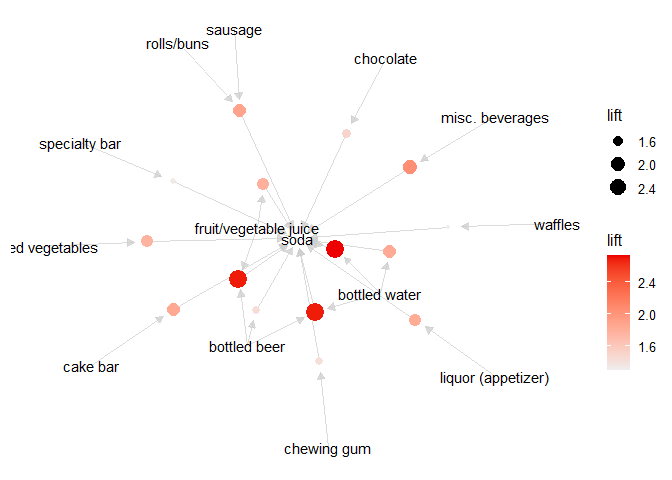

### Shopping Bags:

People who buy more ‘random’ items such as cake, hygiene products, wine, and plants tend to buy shopping bags. Instead of just having shopping bags at check out, it may be beneficial to also have bags throughout the store, specifically along the hygiene and paper products section of the store along with near the bakery.

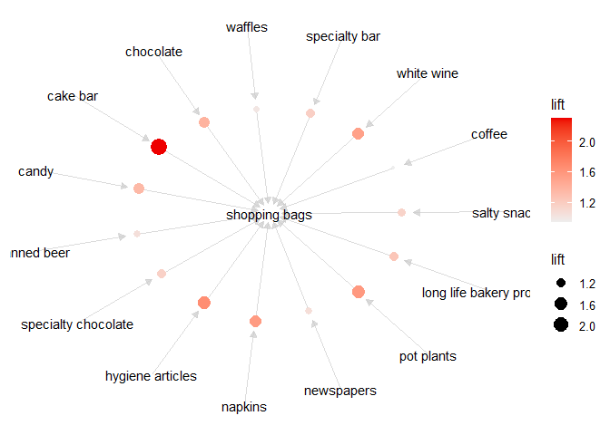

## Conclusion

Let’s take a look back at the overall visual of the rules. After looking at a few patterns above, it is easier to see the groups within this big association visualization. Additionally, we also see newspaper is off to the side - a lot of people come in and just buy that? Let’s have this right by the checkout areas.

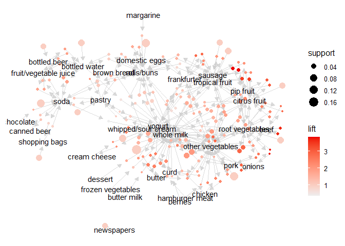

While many people come in and buy a variety of things, by examining the associations between basket items, we can efficiently and effectively organize a grocery store.